# Logistic Regression using GLM

[Sushank Pokhrel (Homepage)](https://sushank.com.np)

Logistic regression models the probability of a binary outcome (e.g., diseased or healthy). Instead of predicting a continuous value, it predicts probabilities that fall between 0 and 1. These probabilities can then be used to classify observations into categories (e.g., >0.5 classified as “diseased”).

#### 1. Importing the Dataset

```r
smoking_data_file <- readxl::read_excel("D:/Drive/r_training/Datasets/smoking_data.xlsx")
```

- `readxl::read_excel()`: Reads Excel files into R.
- `"D:/Drive/r_training/Datasets/smoking_data.xlsx"`: Path to the dataset file.

#### 2. Exploring the Dataset

```r
str(smoking_data_file)
```

```
## tibble [36 × 4] (S3: tbl_df/tbl/data.frame)
##  $ Disease      : chr [1:36] "diseased" "not diseased" "diseased" "diseased" ...
##  $ Age          : num [1:36] 43 18 22 25 45 12 23 33 27 27 ...
##  $ Gender       : chr [1:36] "Male" "Male" "Female" "Male" ...
##  $ Smoker_status: chr [1:36] "Smoker" "Smoker" "Non-smoker" "Non-smoker" ...
```

```r
head(smoking_data_file, n = 10)
```

```
## # A tibble: 10 × 4
##    Disease        Age Gender Smoker_status
##    <chr>        <dbl> <chr>  <chr>
##  1 diseased        43 Male   Smoker
##  2 not diseased    18 Male   Smoker
##  3 diseased        22 Female Non-smoker
##  4 diseased        25 Male   Non-smoker
##  5 not diseased    45 Female Smoker
##  6 not diseased    12 Male   Non-smoker
##  7 diseased        23 Male   Smoker
##  8 diseased        33 Male   Smoker
##  9 not diseased    27 Male   Non-smoker
## 10 not diseased    27 Female Non-smoker
```

- `str()`: Displays the structure of the dataset, including data types (e.g., numeric, character, factor) and a preview of each column.
- `head()`: Shows the first 10 rows of the dataset to understand its contents.

#### 3. Preparing the Data

Data preparation is essential before fitting a logistic regression model. Here, we:

- Convert the outcome variable (Disease) to binary. Diseased = 1 (Yes), Healthy = 0 (No).
- Convert categorical variables to factors. Categorical variables like Gender and Smoker_status are converted into factors to ensure proper handling in the regression.

```r
library(tidyverse)
smoking_data <- smoking_data_file %>%
  mutate(
    Disease = ifelse(Disease == "diseased", 1, 0),  # Binary outcome variable
    Gender = as.factor(Gender),                    # Categorical variable
    Smoker_status = as.factor(Smoker_status)       # Categorical variable
  )
```

- `mutate()`: Creates or modifies columns in the dataset.
- `ifelse(condition, value_if_true, value_if_false)`: Converts the Disease column to binary values (1 for diseased, 0 for healthy).
- `as.factor()`: Converts Gender and Smoker_status to categorical variables, which is crucial for modeling.

#### 4. Logistic Regression Model

The logistic regression model is fitted using the glm() function.

```r
logit_model <- glm(Disease ~ Age + Gender + Smoker_status,
                   data = smoking_data,
                   family = binomial)
```

`glm()` (Generalized Linear Model):

- `Disease ~ Age + Gender + Smoker_status`: Formula specifying the dependent variable (Disease) and independent variables (Age, Gender, Smoker_status).
- `data = smoking_data`: Specifies the dataset.
- `family = binomial`: Indicates that the dependent variable follows a binomial distribution (logistic regression).

#### 5. Summarizing the Model

```r
summary(logit_model)
```

```
##
## Call:
## glm(formula = Disease ~ Age + Gender + Smoker_status, family = binomial,
##     data = smoking_data)
##
## Coefficients:
##                     Estimate Std. Error z value Pr(>|z|)
## (Intercept)         -2.72903    1.26092  -2.164   0.0304 *
## Age                  0.04326    0.02569   1.684   0.0922 .
## GenderMale           0.86957    0.80482   1.080   0.2799
## Smoker_statusSmoker  1.33689    0.78579   1.701   0.0889 .
## ---
## Signif. codes:  0 '***' 0.001 '**' 0.01 '*' 0.05 '.' 0.1 ' ' 1
##
## (Dispersion parameter for binomial family taken to be 1)
##
##     Null deviance: 49.461  on 35  degrees of freedom
## Residual deviance: 40.670  on 32  degrees of freedom
## AIC: 48.67
##
## Number of Fisher Scoring iterations: 4
```

- `summary()`: Provides detailed output for the logistic regression model.
- `Coefficients`: Estimates for each predictor (log-odds).
- `p-values`: Indicates the significance of predictors.
- `Deviance Residuals`: Assess the goodness-of-fit.
- `Null vs Residual Deviance`: Measures how well the model fits compared to a null model (without predictors).

Key Results:

- Intercept: Log-odds when all predictors are at their baseline levels.
- Predictor Coefficients: Change in log-odds for a one-unit increase in the predictor.
- Positive coefficient: Increases likelihood of being diseased.
- Negative coefficient: Decreases likelihood of being diseased.

#### 6. Multicollinearity Assessment

It is necessary to study if the predictor variables are correlated to each other, for which we use pearson correlation and Variance Inflation Factor. Generally, the parameters with correlation > |0.7| are removed from the final model, due to their greater collinearity. Similarly, the paramenters with VIF > 10 are also removed.

Here, we are performing the test by using VIF only. To understand Pearson correlation, please refer to correlation and regression section of the tutorial.

```r
# VIF

car::vif(logit_model)
```

```
##           Age        Gender Smoker_status
##      1.031620      1.058580      1.051891
```

The parameters don’t have multicollinearity problem.

#### 6. Odds Ratios and Confidence Intervals

Log-odds are transformed into odds ratios for easier interpretation.

```r
exp(cbind(OR = coef(logit_model), confint(logit_model)))
```

```
##                             OR       2.5 %     97.5 %
## (Intercept)         0.06528273 0.003710926  0.6141511
## Age                 1.04421362 0.999376556  1.1113980
## GenderMale          2.38589412 0.511917176 12.8409893
## Smoker_statusSmoker 3.80719721 0.846124680 19.5031504
```

- `exp()`: Converts log-odds into odds ratios.
- `Odds ratio > 1`; Predictor increases the likelihood of disease.
- `Odds ratio < 1`; Predictor decreases the likelihood of disease.
- `confint()`: Calculates 95% confidence intervals for coefficients.

#### 7. Predicting Probabilities

After fitting the model, we calculate the probability of being diseased for each individual.

```r
smoking_data$predicted_prob <- predict(logit_model, type = "response")
```

- `predict()`: Predicts outcomes based on the model.
- `type = "response"`: Returns predicted probabilities (values between 0 and 1).

#### 8. Classifying Predictions

We classify individuals as “diseased” if their predicted probability >0.5

```r
smoking_data <- smoking_data %>%
  mutate(predicted_class = ifelse(predicted_prob > 0.5, 1, 0))

smoking_data |> head(20)
```

```
## # A tibble: 20 × 6
##    Disease   Age Gender Smoker_status predicted_prob predicted_class
##      <dbl> <dbl> <fct>  <fct>                  <dbl>           <dbl>
##  1       1    43 Male   Smoker                 0.792               1
##  2       0    18 Male   Smoker                 0.564               1
##  3       1    22 Female Non-smoker             0.145               0
##  4       1    25 Male   Non-smoker             0.315               0
##  5       0    45 Female Smoker                 0.635               1
##  6       0    12 Male   Non-smoker             0.207               0
##  7       1    23 Male   Smoker                 0.616               1
##  8       1    33 Male   Smoker                 0.712               1
##  9       0    27 Male   Non-smoker             0.334               0
## 10       0    27 Female Non-smoker             0.174               0
## 11       1    48 Female Smoker                 0.665               1
## 12       1    34 Female Smoker                 0.520               1
## 13       1    32 Female Smoker                 0.498               0
## 14       1    66 Male   Smoker                 0.912               1
## 15       0    24 Male   Smoker                 0.626               1
## 16       1    34 Male   Non-smoker             0.404               0
## 17       0    27 Male   Non-smoker             0.334               0
## 18       0    34 Female Smoker                 0.520               1
## 19       1    55 Male   Smoker                 0.865               1
## 20       1    65 Male   Smoker                 0.908               1
```

- `ifelse()`: Converts probabilities into binary classes: >0.5: Diseased (1) and ≤0.5: Not diseased (0).

#### 9. Confusion Matrix

The confusion matrix compares the predicted classifications with the actual disease status.

```r
confusion_matrix <- table(smoking_data$Disease, smoking_data$predicted_class)
confusion_matrix
```

```
##
##      0  1
##   0 11  5
##   1  5 15
```

- `table()`: Creates a cross-tabulation of actual vs predicted classes.
- `Rows`: Actual Disease status.
- `Columns`: Predicted predicted_class.

##### Confusion Matrix/Error Matrix Example.

|  | Predicted No (0) | Predicted Yes (1) |
| --- | --- | --- |
| **Actual No** | True Negatives | False Positives |
| **Actual Yes** | False Negatives | True Positives |

#### 10. True Skill Statistic (TSS) or Youden’s Index

TSS (Youden’s Index): Provides a single measure balancing sensitivity and specificity, useful for model comparison.

TSS Values range from -1 to +1:

- +1: Perfect prediction.
- 0: Random prediction (no skill).
- −1: Perfectly incorrect predictions.

Extracting the elements from confusion matrix.

```r
TN <- confusion_matrix[1, 1]  # True Negatives
FP <- confusion_matrix[1, 2]  # False Positives
FN <- confusion_matrix[2, 1]  # False Negatives
TP <- confusion_matrix[2, 2]  # True Positives

c(TN, FP, FN, TP) |> print()
```

```
## [1] 11  5  5 15
```

Confusion Matrix Elements:

- **True Negatives (TN)**: Cases correctly classified as negative (healthy).
- **False Positives (FP)**: Cases incorrectly classified as positive (diseased).
- **False Negatives (FN)**: Cases incorrectly classified as negative.
- **True Positives (TP)**: Cases correctly classified as positive.

```r
sensitivity <- TP / (TP + FN)
specificity <- TN / (TN + FP)

TSS = sensitivity + specificity - 1
TSS
```

```
## [1] 0.4375
```

Sensitivity (True Positive Rate) Measures the model’s ability to correctly identify positive cases. Specificity (True Negative Rate): Measures the model’s ability to correctly identify negative cases.

#### 10. Receiver Operating Characteristic (ROC) Curve

A graph that plots the True Positive Rate (Sensitivity) against the False Positive Rate (1 - Specificity) for different threshold values. It offers visual and numerical summery of model performance across different thresholds. It helps visualize the trade-off between sensitivity and specificity.

We need the package `pROC` for developing the plot.

```r
library(pROC)
```

```r
roc_curve <- roc(smoking_data$Disease, smoking_data$predicted_prob)
roc_curve
```

```
##
## Call:
## roc.default(response = smoking_data$Disease, predictor = smoking_data$predicted_prob)
##
## Data: smoking_data$predicted_prob in 16 controls (smoking_data$Disease 0) < 20 cases (smoking_data$Disease 1).
## Area under the curve: 0.7797
```

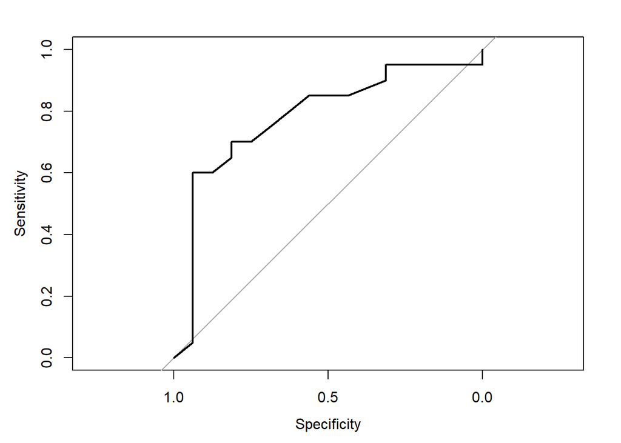

```r
plot(roc_curve)
```

Inputs: Actual values `(smoking_data$Disease)` and predicted probabilities `(smoking_data$predicted_prob)`.

#### 11. Area Under Curve (AUC) value of ROC.

AUC quantifies the overall performance of the model.

AUC values:

- `0.5`: Random prediction.
- `>0.7`: Acceptable.
- `>0.8`: Good.
- `>0.9`: Excellent.

```r
auc(roc_curve)
```

```
## Area under the curve: 0.7797
```

#### 12. Visualizing Predicted Probabilities by Age

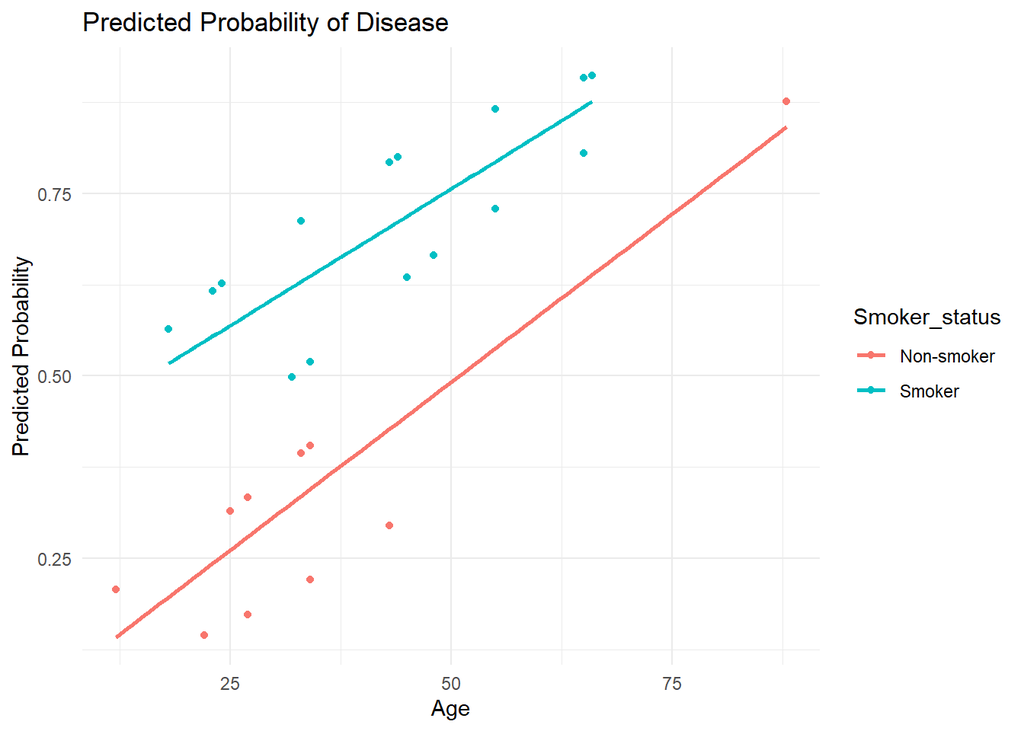

```r
ggplot(smoking_data, aes(x = Age, y = predicted_prob, color = Smoker_status)) +
  geom_point() +
  geom_smooth(method = "glm", se = FALSE) +
  labs(title = "Predicted Probability of Disease",
       y = "Predicted Probability",
       x = "Age") +
  theme_minimal()
```

- `aes(x = Age, y = predicted_prob, color = Smoker_status)`: Maps Age to the x-axis, predicted_prob to the y-axis, and colors the points by Smoker_status.
- `geom_point()`: Adds individual data points to the plot.
- `geom_smooth(method = "glm", se = FALSE)`: Adds a smoothed trend line using logistic regression (method = “glm”). se = FALSE: Removes the confidence interval shading.
- `labs()`: Labels for the title, x-axis, and y-axis.
- `theme_minimal()`: A clean theme for better readability.

#### 13. Predicting Probabilities for New Data

Developing new data for prediction. This dataset represents hypothetical individuals for whom we want to predict the probability of being diseased.

```r
new_data <- data.frame(
  Age = c(30, 45, 60),
  Gender = c("Male", "Female", "Male"),
  Smoker_status = c("Smoker", "Non-smoker", "Smoker")
)
```

Data cleaning. Converting Categorical Variables. Gender and Smoker_status are converted to factors to match the format of the original model.

```r
new_data$Gender <- as.factor(new_data$Gender)
new_data$Smoker_status <- as.factor(new_data$Smoker_status)
```

Prediction * Predicts probabilities for the new dataset using the logistic regression model `(logit_model)`.

```r
new_data$predicted_prob <- predict(logit_model, newdata = new_data, type = "response")
print(new_data)
```

```
##   Age Gender Smoker_status predicted_prob
## 1  30   Male        Smoker      0.6846797
## 2  45 Female    Non-smoker      0.3138580
## 3  60   Male        Smoker      0.8882793
```

- `newdata = new_data`: Specifies the new dataset for prediction.
- `type = "response"`: Returns predicted probabilities (values between 0 and 1).
- The `predicted_prob` column in new_data contains the predicted probabilities of disease for each individual.

We can convert it into binary results as 0 (Not Diseased) and 1 (Diseased)

```r
new_data <- new_data %>%
  dplyr::mutate(predicted_class = ifelse(predicted_prob > 0.5, 1, 0))

print(new_data)
```

```
##   Age Gender Smoker_status predicted_prob predicted_class
## 1  30   Male        Smoker      0.6846797               1
## 2  45 Female    Non-smoker      0.3138580               0
## 3  60   Male        Smoker      0.8882793               1
```

### Performing the model with lower number of predictors to study AIC.

```r
# Fit a reduced model
reduced_model <- glm(Disease ~ Age + Smoker_status,
                     data = smoking_data,
                     family = binomial)
```

Here, only two of the parameters are used.

Comparing the current model with the previous one using AIC (Akaike Information Criterion)

```r
AIC(logit_model, reduced_model)
```

```
##               df      AIC
## logit_model    4 48.66970
## reduced_model  3 47.88113
```

AIC, or Akaike Information Criterion, is a widely used metric for comparing statistical models. It is particularly helpful for model selection when you are deciding which variables to include in a regression model. The AIC provides a balance between model fit and model complexity, favoring simpler models that explain the data well.

- The model with the lowest AIC is generally preferred because it balances goodness of fit and simplicity.
- Models with more parameters (more predictors) have lower log-likelihood due to better fit but are penalized. This prevents overfitting by discouraging unnecessary predictors.
- AIC is not an absolute measure but is used to compare models. It does not provide the absolute quality of a model.
- If two models have similar AIC values (difference less than 2), the simpler model is usually preferred.

Here, the two models have relatively similar values; therefore, the latter model is preferred as it has lower predictor variables. This is because it is easier to understand and read the model with lower predictor variables. Furthermore, in our case, the removal of `Gender` did not significantly lower the model prediction capability.

In addition, other model evaluation parameters, such as AUC, TSS can be used.